# Creating the `independencepvalue` R package

Arkajyoti Saha

November 22, 2022

Note: This package was generated using the `litr` R package, which lets you define full R packages in a single R Markdown file. For more on `litr`, see [here](https://github.com/jacobbien/litr-project/tree/main/litr).

## Package setup

We start by specifying the information needed in the DESCRIPTION file of the R package.

```r
usethis::create_package(
  path = ".",
  fields = list(
    Package = params$package_name,
    Version = "0.0.2",
    Title = "Testing independence between groups of Gaussian variables",
    Description = "Discovers block diagonal structure from a given covariance matrix through thresholding correlations and then tests whether a block is independent from the remaining variables in a fashion that accounts for the selection of the blocks.  A function for testing in the classical setting where these groups are predetermined is also implemented.",
    `Authors@R` = c(person(
      given = "Arkajyoti",
      family = "Saha",
      email = "arkajyotisaha93@gmail.com",
      role = c("aut", "cre")
      ), person("Daniela", "Witten", role="aut", email="dwitten@u.washington.edu"), person("Jacob", "Bien", role="aut", email="jbien@usc.edu"))
  )
)
usethis::use_mit_license(copyright_holder = "A. Saha")
```

## Introduction

Consider

$${\bf X}\sim N_{n\times p}(0,{\bf I}_n,{\boldsymbol\Sigma})$$

Given a realization ${\bf x}$ of ${\bf X}$, this package implements tests of whether a particular block of the covariance matrix is zero or not, i.e.

$$H_0^{\mathcal P}:{\boldsymbol\Sigma}_{{\mathcal P},{\mathcal P}^c}={\bf 0}~~\text{versus}~~H_1^{\mathcal P}:{\boldsymbol\Sigma}_{{\mathcal P},{\mathcal P}^c}\neq{\bf 0}.$$
There are three main parts to the code in this package:

1. P-values in the case of pre-specified groups: We compute the p-value under the classical context in which ${\mathcal P}$ is assumed to be pre-specified (i.e., not selected based on the data used for testing). While this is not the focus of the package, some users may find this useful, and it will also be useful in the third part.
2. Partitioning variables into groups: Here we implement a straightforward partitioning strategy based on thresholding the correlation matrix.
3. P-values in the case of selected groups: This is the heart of the package. It computes p-values in the case that ${\mathcal P}$ is the result of the partitioning implemented in part 2. Since in this case the group of variables is data-dependent, we write our tested hypothesis as
   $$H_0^{\hat{\mathcal P}({\bf x})}:{\boldsymbol\Sigma}_{\hat{\mathcal P}({\bf x}),\hat{\mathcal P}({\bf x})^c}={\bf 0}~~\text{versus}~~H_1^{\hat{\mathcal P}({\bf x})}:{\boldsymbol\Sigma}_{\hat{\mathcal P}({\bf x}),\hat{\mathcal P}({\bf x})^c}={\bf 0}.$$

## Functions in the package

First, we import some required packages:

```r
usethis::use_package("stats")
usethis::use_package("future.apply")
```

We use `future.apply` for parallelizing some of the computations.

### When groups are pre-specified

We first focus on computing the p-value when the group ${\mathcal P}$ is pre-specified.

First, given the group ${\mathcal P}$, we use (4)-(5) of the paper to compute the test statistic as a function of the canonical correlations as follows. First, we compute the cross-covariance matrix $({\bf S}_{{\mathcal P},{\mathcal P}^c}^W)$ of the ‘whitened’ variables.

$${\bf S}_{{\mathcal P},{\mathcal P}^c}^W = {\bf S}_{{\mathcal P},{\mathcal P}}^{-\frac{1}{2}}{\bf S}_{{\mathcal P},{\mathcal P}^c}{\bf S}_{{\mathcal P}^c,{\mathcal P}^c}^{-\frac{1}{2}}.$$
We obtain the singular value decomposition (SVD) of ${\bf S}_{{\mathcal P},{\mathcal P}^c}^W$ as follows:
$${\bf S}_{{\mathcal P},{\mathcal P}^c}^W = \hat{{\bf A}}\hat{{\boldsymbol\Lambda}}\hat{{\boldsymbol\Gamma}}^\top,$$
where $\hat{{\boldsymbol\Lambda}} := \mathrm{diag}(\hat{\lambda}_1, \hat{\lambda}_2, \ldots, \hat{\lambda}_r)$ is the diagonal matrix of the $r = r({\mathcal P}):=\min\{|{\mathcal P}|,|{\mathcal P}^c|\}$ singular values of ${\bf S}_{{\mathcal P},{\mathcal P}^c}^W$ and $\hat{{\bf A}}$ and $\hat{{\boldsymbol\Gamma}}$ are the canonical vectors from doing a CCA on ${\bf X}_{{\mathcal P}}$ and ${\bf X}_{{\mathcal P}^c}$. $\hat{\lambda}_1, \hat{\lambda}_2, \ldots, \hat{\lambda}_r$ can be interpreted as the canonical correlations between the variables in ${\mathcal P}$ and ${\mathcal P}^c$. The test statistics is given by $\prod_{i = 1}^r (1 - \hat{\lambda_i}^2)$. To compute this, we define a function that given a covariance matrix ${\bf S}$ and a group ${\mathcal P}$, computes and returns the test statistic along with ${\bf S}_{{\mathcal P},{\mathcal P}}$, ${\bf S}_{{\mathcal P}^c,{\mathcal P}^c}$, the left and right canonical vectors of ${\bf S}_{{\mathcal P},{\mathcal P}^c}$, i.e. ${\bf S}_{{\mathcal P},{\mathcal P}}^{\frac{1}{2}}\hat{{\bf A}}$ and ${\bf S}_{{\mathcal P}^c,{\mathcal P}^c}^{\frac{1}{2}}\hat{{\boldsymbol\Gamma}}$, since we will be using these information when testing in the selective context. As the test statistic is identical with ${\mathcal P}$ and ${\mathcal P}^c$ interchanged, this function will swap ${\mathcal P}$ and ${\mathcal P}^c$ if needed to ensure that $|{\mathcal P}|\ge p/2$. This ensures that $|{\mathcal P}| \ge |{\mathcal P}|^c$. Since $r =\min\{|{\mathcal P}|,|{\mathcal P}^c|\}$, this code ensures that $r=|{\mathcal P}^c|$. Moreover, for the remainder of the document, we denote $p_1:=|{\mathcal P}|$ and $p_2 := |{\mathcal P}^c| = p - p_1$.

```r
#' Compute the test statistic as a function of canonical correlations.
#'
#' Given a sample covariance matrix \eqn{S} and a group of variables \eqn{P}, first
#' computes the cross-covariance matrix between the whitened variables:
#' \eqn{S_{P, P^c}^W = S_{P, P}^{-0.5} S_{P, P^c} S_{P^c, P^c}^{-0.5}}. Next,
#' computes the SVD of \eqn{S_{P, P^c}^W} and returns the test statistic,
#' \eqn{S_{P, P}}, \eqn{S_{P^c, P^c}} and the canonical vectors
#' of \eqn{S_{P, P^c}}.
#'
#' @param S a \eqn{p \times p} sample covariance matrix
#' @param CP a vector of length \eqn{p} with \eqn{i^{th}} element denoting the
#' group \eqn{i^{th}} variable belongs to
#' @param k the group to be tested for independence with the remaining variables, i.e. \eqn{P = i : CP[i]==k}
#' @return A list containing the following items:
#' \item{statistic}{Test statistic corresponding to \eqn{S} and group of variables \eqn{P}.}
#'
#' \item{S11}{\eqn{S_{P, P}} if \eqn{2|P| \ge p}, else \eqn{S_{P^c, P^c}}.}
#'
#' \item{S22}{\eqn{S_{P^c, P^c}} if \eqn{2|P| \ge p}, else \eqn{S_{P, P}}.}
#'
#' \item{left_SV}{Left canonical vectors of  \eqn{S_{P, P^c}}.}
#'
#' \item{right_SV}{Right canonical vectors of \eqn{S_{P, P^c}}.}
#'
#' @keywords internal
test_stat_CCA <- function(S, CP, k) {
  p <- nrow(S)
  ptemp <- sum(CP==k)
  if(2*ptemp >= p){
    S11_x <- as.matrix(S[which(CP==k), which(CP==k)])#S11
    S22_x <- as.matrix(S[which(CP!=k), which(CP!=k)])#S22
    S12_x <- as.matrix(S[which(CP==k), which(CP!=k)])#S_12
  }
  if(2*ptemp < p){
    S11_x <- as.matrix(S[which(CP!=k), which(CP!=k)])#S11
    S22_x <- as.matrix(S[which(CP==k), which(CP==k)])#S22
    S12_x <- as.matrix(S[which(CP!=k), which(CP==k)])#S_12
  }
  #ensures that p2 <= p1.
  S11_x_half <- amen::mhalf(S11_x)#S_11^{1/2}
  inv_S11_x_half <- solve(S11_x_half)#S_11^{-1/2}
  S22_x_half <- amen::mhalf(S22_x)#S_11^{1/2}
  inv_S22_x_half <- solve(S22_x_half)#S_11^{-1/2}
  tilde_S12_x <- inv_S11_x_half %*% S12_x %*% inv_S22_x_half#S_12^W = covariance matrix of whitened X_1 and X_2
  svdecom <- svd(tilde_S12_x)#compact SVD
  singular_values <- svdecom$d#lambda
  test_stat <- prod(1-singular_values^2)#test statistic
  L_x <- S11_x_half %*% svdecom$u
  R_x <- t(svdecom$v) %*% S22_x_half
  return(list(statistic=test_stat, S11 = S11_x, S22_x = S22_x, left_SV=L_x, right_SV=t(R_x)))
}
```

We also add a code to test the function `test_stat_CCA()` works:

```r
testthat::test_that("test_stat_CCA() works", {
  set.seed(1)
  X <- matrix(rnorm(50), 10, 5)
  testthat::expect_equal(
    round(test_stat_CCA(S=cov(X), CP=rep(1:2, times=c(3, 2)), k=1)$statistic, 2),
    0.62)
  set.seed(1)
  X <- matrix(rnorm(50), 10, 5)
  # testing group 2 should give identical results:
  testthat::expect_equal(
    round(test_stat_CCA(S=cov(X), CP=rep(1:2, times=c(3, 2)), k=2)$statistic, 2),
    0.62)
})
```

```
## Test passed 🌈
```

We have used the `amen::mhalf()` for computing the symmetric square root of a matrix, so we import this package:

```r
usethis::use_package("amen")
```

Next to compute the p-value of the test statistic, we will be sampling from the distribution of the test statistic under the null. For pre-specified groups, this is given by a Wilks’ lambda distribution, and we can use Proposition 1(ii) of the paper to simulate from it as follows.

We sample two independent Wishart matrices,

$${\bf W}\sim\text{Wishart}({\bf I}_{r},p-r)\text{ and }{\bf T}\sim\text{Wishart}({\bf I}_{r},n-1-p+r),$$

then compute the eigenvalues of ${\bf W}{\bf T}^{-1}$, which we call $(\Psi_1,\ldots,\Psi_r)$. Then the test statistic is given by

$$\prod_{i=1}^r(1-\lambda_i^2)=\prod_{i=1}^r\left(1-\frac{\Psi_i}{1+\Psi_i}\right)=\frac{1}{\prod_{i=1}^r(1+\Psi_i)}.$$

We start by defining a function that generates the random vector $(\Psi_1,\ldots,\Psi_r)$ since we’ll be using this function again when sampling in the selective context.

```r
#' Sample from the distribution of eigenvalues of W * inv(T)
#'
#' Samples from the \code{rp}-dimensional joint distribution of the eigenvalues of
#' \eqn{WT^{-1}}, where \eqn{W} and \eqn{T} are independent Wisharts with dimensions specified
#' in Prop 1(ii).  These are the \eqn{\Psi_i}, and taking \eqn{\sqrt{(\Psi_i/(1+\Psi_i))}}
#' gives a sample from the joint distribution of the canonical correlations
#' between two groups of variables of size \eqn{p_1} and \eqn{p_2} under the null.
#'
#' @param p \eqn{p_1+p_2}
#' @param rp \eqn{min(p_1, p_2)}
#' @param n sample size
#' @return A vector of length \code{rp} sampled from the joint distribution described
#' above.
#' @keywords internal
sample_psi <- function(p, rp, n) {
  tilde_W_X <- stats::rWishart(1, p - rp, diag(rp))#simulate W
  tilde_T_X <- stats::rWishart(1, n - (p - rp) - 1, diag(rp))#simulate T
  tilde_F_X <- tilde_W_X[,,1] %*% solve(tilde_T_X[,,1])# inv(W)T
  return(eigen(tilde_F_X)$values) # eigenvalues of (inv(W)T)
}
```

We use the above function in the following function, which samples from the null distribution of the test statistic:

```r
#' Function for Monte Carlo simulation for classical inference
#'
#' Samples from the joint distribution of the canonical correlations between two groups of independent Gaussian variables of size \eqn{p_1} and \eqn{p_2} using \code{sample_psi()}, and then computes the corresponding test statistic, which follows a Wilks' lambda distribution.
#'
#' @param p \eqn{p_1+p_2}
#' @param rp \eqn{min(p_1, p_2)}
#' @param n sample size
#' @return A sample from Wilks' lambda distribution.
#' @keywords internal
MC_function_classical <- function(p, rp, n){
  F_X_eigenvalues <- sample_psi(p, rp, n) # eigenvalues of (inv(W)T)
  while(any(F_X_eigenvalues < 0)){
    F_X_eigenvalues <- sample_psi(p, rp, n) # eigenvalues of (inv(W)T)
  }
  statistic <- 1/prod(1+F_X_eigenvalues)
  # prod(1 - lambda_i^2) = prod(1 - Psi_i/(1 + Psi_i)) = prod(1/(1 + Psi_i))
  return(statistic)
}
```

As noted in Prop 1(iii) of the paper, when $r=1$ this can be done by sampling

$$\lambda_1^2\sim\text{Beta}([p-1]/2, [n-p]/2)$$

and then computing $(1-\lambda_1^2)$. Let’s do a visual check of `MC_function_classical()` by making sure it matches up with this other approach in the $r=1$ case.

```r
set.seed(123)
p <- 5
n <- 20
nsim <- 1e4
from_wisharts <- sapply(1:nsim,
                        function(i) MC_function_classical(p = p, rp = 1, n = n))
from_beta <- 1 - rbeta(nsim, (p - 1) / 2, (n - p) / 2)
```

Do the quantiles from the two approaches match?

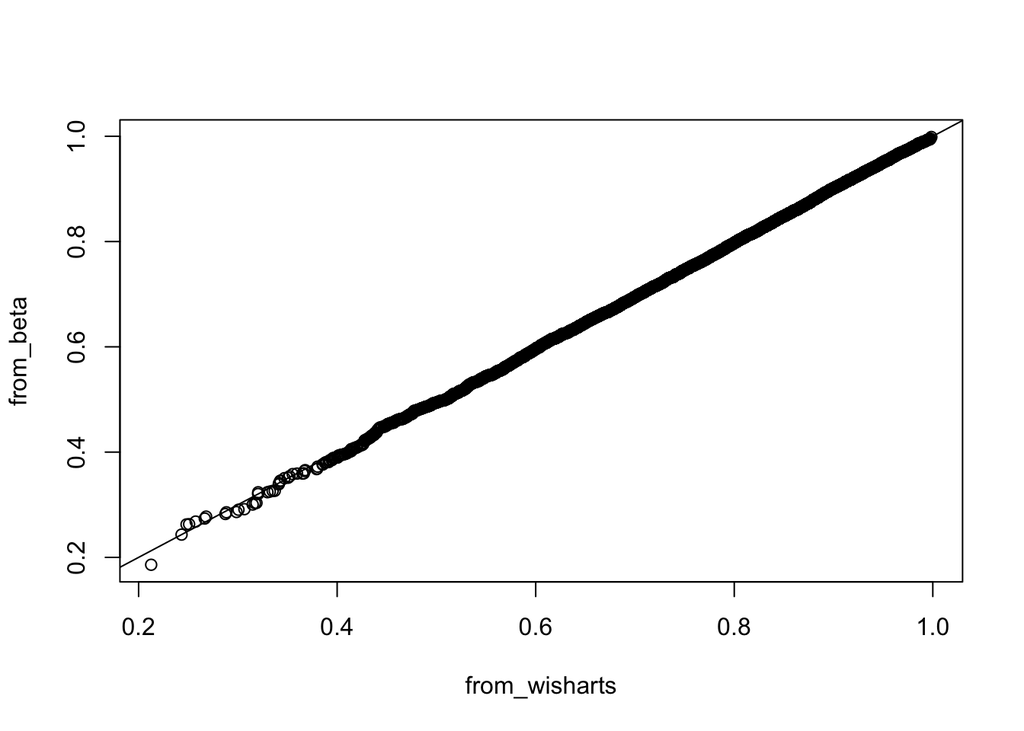

```r
qqplot(from_wisharts, from_beta)
abline(0, 1)
```

Yes, ok good.

Let’s make a test based on the $r=1$ case:

```r
testthat::test_that("MC_function_classical() works", {
  set.seed(123)
  p <- 5
  n <- 20
  nsim <- 1e4
  from_wisharts <- sapply(1:nsim,
                          function(i) MC_function_classical(p = p, rp = 1, n = n))
  from_beta <- 1 - rbeta(nsim, (p - 1) / 2, (n - p) / 2)
  probs <- seq(0.05, 0.95, length = 10)
  qw <- quantile(from_wisharts,probs = probs)
  qb <- quantile(from_beta,probs = probs)
  testthat::expect_true( all(abs(qw - qb) < 0.01) )
})
```

```
## Test passed 🥳
```

Next, we make use of `MC_function_classical()` within a function for testing the independence of two pre-specified groups of variables. The idea is to compute the observed value of the test statistic and then compare it to a large number of Monte Carlo samples from the null distribution of the test statistic. When $r=1$, we do not need to use Monte Carlo sampling; rather, we use the cdf of the beta distribution described above.

```r
#' Function to test the independence of two pre-specified groups of variables
#'
#' Given a covariance matrix \eqn{S} of \eqn{p} Gaussian variables, and a pre-specified group
#' of variables \eqn{P}, this function tests the null hypothesis of independence between the groups of
#' variables in \eqn{P} and \eqn{P^c}. Makes use of \code{test_stat_CCA()} and \code{sample_psi()}.
#'
#' @param S a \eqn{p \times p} covariance matrix
#' @param CP a vector of length \eqn{p} with \eqn{i^{th}} element denoting the
#' group \eqn{i^{th}} variable belongs to
#' @param k the group to be tested for independence with the remaining variables, i.e. \eqn{P = [i : CP[i]==k]}
#' @param n sample size
#' @param mc_iter the number of Monte Carlo iterations used to approximate the p-value; we recommend using a high value of this to obtain an approximation with high accuracy; default value is 1,000
#' @return The p-value for the test of independence.
#' @examples
#' # Simulates a 10 x 3 X_1 from N(0, I)
#' set.seed(1)
#' X_1 <- matrix(rnorm(30), 10, 3)
#'
#' # Simulates a 10 x 2 X_2 from N(0, I) independently of X_1
#' set.seed(2)
#' X_2 <- matrix(rnorm(20), 10, 2)
#'
#' # Compute the covariance matrix of X = (X_1 X_2).
#' covX <- cov(cbind(X_1, X_2))
#' # tests for a difference in means between X_1 and X_2
#' classical_p_val(S=covX, CP=rep(1:2, times=c(3, 2)), k=1, n=10, mc_iter=100)
#' @export
classical_p_val <- function(S, CP, k, n, mc_iter= 1000){
  test_hyp <- test_stat_CCA(S, CP, k)
  p <- nrow(S)
  rp <- nrow(test_hyp$S22)
  if(rp == 1){
    classic_p_val <- 1 - stats::pbeta(1-test_hyp$statistic, (p - 1)/2, (n - p)/2)
    # for r(p) = 1, we have more efficient way to compute p_value based on beta distribution.
  }
  if(rp > 1){
    sip <- future.apply::future_sapply(1:mc_iter, function(i) MC_function_classical(p, rp, n), future.seed = TRUE)
    #MC simulation to approximate the p-value.
    classic_p_val <- mean(test_hyp$statistic >= sip)#computes p-value. The test statistic is smaller if it is away from null.
  }
  return(classic_p_val)
}
```

Here’s an example use of the `classical_p_val()`:

```r
# Simulates a 10 x 3 \eqn{X_1} from \eqn{N(0, I)}
set.seed(1)
X_1 <- matrix(rnorm(30), 10, 3)

# Simulates a 10 x 2 \eqn{X_2} from \eqn{N(0, I)} independently of \eqn{X_1}
set.seed(2)
X_2 <- matrix(rnorm(20), 10, 2)
# Compute the covariance matrix of \eqn{X} = (\eqn{X_1} \eqn{X_2}).
covX <- cov(cbind(X_1, X_2))
# tests for a difference in means between \eqn{X_1} and \eqn{X_2}
classical_p_val(S=covX, CP=rep(1:2, times=c(3, 2)), k=1, n=10, mc_iter=100)
```

```
## [1] 0.08
```

We also add a test of the function `classical_p_val()`:

```r
testthat::test_that("classical_p_val() works", {
  testthat::skip_on_cran()
  nsim <- 1e3
  simulation_classical <- function(i){
    set.seed(i)
    X <- matrix(rnorm(50), 10, 5)
    return(classical_p_val(S=cov(X), CP=rep(1:2, times=c(3, 2)), k=1, n=10, mc_iter=100))
  }
  classical_pval <- future.apply::future_sapply(1:nsim, simulation_classical, future.seed = TRUE)
  probs <- seq(0.05, 0.95, length = 10)
  qw <- quantile(classical_pval, probs = probs)
  testthat::expect_true(all(abs(qw - probs) < 0.025) )
})
```

```
## Test passed 🥇
```

We add an additional test to check if the function `classical_p_val()` works in the case of $r=1$.

```r
testthat::test_that("classical_p_val() works for r=1", {
  testthat::skip_on_cran()
  nsim <- 1e4
  simulation_classical <- function(i){
    set.seed(i)
    X <- matrix(rnorm(50), 10, 5)
    return(classical_p_val(S=cov(X), CP=rep(1:2, times=c(1, 4)), k=1, n=10, mc_iter=100))
  }
  classical_pval <- future.apply::future_sapply(1:nsim, simulation_classical, future.seed = TRUE)
  probs <- seq(0.05, 0.95, length = 10)
  qw <- quantile(classical_pval, probs = probs)
  testthat::expect_true(all(abs(qw - probs) < 0.005) )
})
```

```
## Test passed 🎉
```